# Telecom Customer Churn - Exploratory Data Analysis

**Churn** is when a paying customer cancels the service. It matters commercially because acquiring a replacement customer costs several times more than keeping an existing one, so a churn rate is really a measure of how much the business must spend just to stand still.

In this dataset **26.5% of customers have churned** - roughly one in four. That is high enough that the interesting question is not *"do we have a churn problem?"* but *"which customers churn, and what do they have in common?"*

### How to read every chart in this notebook

Most churn analyses plot **counts** of churned customers, and that is misleading: the largest group will always contain the most churners simply because it is the largest. So nearly every chart here plots the **churn rate within each group** instead, with the group size `n` under each bar and a dashed line at the overall 26.5% baseline.

> **Above the dashed line = a risk segment (red). Below it = a safe segment (blue).**

## 1. Setup

All imports live in this one cell so the notebook runs top-to-bottom from a fresh kernel.

```python
# Data handling
import pandas as pd
import numpy as np

# Visualisation
import matplotlib.pyplot as plt

pd.set_option("display.max_columns", None)
pd.set_option("display.width", 120)

# --- Chart theme ---------------------------------------------------------
# The built-in "ggplot" theme supplies the whole look: grey panel, white grid,
# and its own colour cycle. The only thing we take from it by hand are the first
# two cycle colours, so the risk/safe rule stays the same on every chart.
plt.style.use("ggplot")

RISK, SAFE = plt.rcParams["axes.prop_cycle"].by_key()["color"][:2]   # red, blue

print("Libraries loaded. pandas", pd.__version__, "| numpy", np.__version__)
print("ggplot theme applied - risk =", RISK, "| safe =", SAFE)
```

```
Libraries loaded. pandas 2.3.3 | numpy 1.26.4
ggplot theme applied - risk = #E24A33 | safe = #348ABD
```

## 2. Load the data - first look

```python
url = "https://raw.githubusercontent.com/YBIFoundation/Dataset/main/TelecomCustomerChurn.csv"
df = pd.read_csv(url)

print("Rows:", df.shape[0], " Columns:", df.shape[1])
```

```
Rows: 7043  Columns: 21
```

```python
df.head()
```

|  | customerID | Gender | SeniorCitizen | Partner | Dependents | Tenure | PhoneService | MultipleLines | InternetService | OnlineSecurity | OnlineBackup | DeviceProtection | TechSupport | StreamingTV | StreamingMovies | Contract | PaperlessBilling | PaymentMethod | MonthlyCharges | TotalCharges | Churn |
| --- | --- | --- | --- | --- | --- | --- | --- | --- | --- | --- | --- | --- | --- | --- | --- | --- | --- | --- | --- | --- | --- |
| 0 | 7590-VHVEG | Female | 0 | Yes | No | 1 | No | No | DSL | No | Yes | No | No | No | No | Monthly | Yes | Manual | 29.85 | 29.85 | No |
| 1 | 5575-GNVDE | Male | 0 | No | No | 34 | Yes | No | DSL | Yes | No | Yes | No | No | No | One year | No | Manual | 56.95 | 1889.5 | No |
| 2 | 3668-QPYBK | Male | 0 | No | No | 2 | Yes | No | DSL | Yes | Yes | No | No | No | No | Monthly | Yes | Manual | 53.85 | 108.15 | Yes |
| 3 | 7795-CFOCW | Male | 0 | No | No | 45 | No | No | DSL | Yes | No | Yes | Yes | No | No | One year | No | Bank transfer (automatic) | 42.30 | 1840.75 | No |
| 4 | 9237-HQITU | Female | 0 | No | No | 2 | Yes | No | Fiber optic | No | No | No | No | No | No | Monthly | Yes | Manual | 70.70 | 151.65 | Yes |

```python
df.info()
```

```
<class 'pandas.core.frame.DataFrame'>
RangeIndex: 7043 entries, 0 to 7042
Data columns (total 21 columns):
 #   Column            Non-Null Count  Dtype
---  ------            --------------  -----
 0   customerID        7043 non-null   object
 1   Gender            7043 non-null   object
 2   SeniorCitizen     7043 non-null   int64
 3   Partner           7043 non-null   object
 4   Dependents        7043 non-null   object
 5   Tenure            7043 non-null   int64
 6   PhoneService      7043 non-null   object
 7   MultipleLines     7043 non-null   object
 8   InternetService   7043 non-null   object
 9   OnlineSecurity    7043 non-null   object
 10  OnlineBackup      7043 non-null   object
 11  DeviceProtection  7043 non-null   object
 12  TechSupport       7043 non-null   object
 13  StreamingTV       7043 non-null   object
 14  StreamingMovies   7043 non-null   object
 15  Contract          7043 non-null   object
 16  PaperlessBilling  7043 non-null   object
 17  PaymentMethod     7043 non-null   object
 18  MonthlyCharges    7043 non-null   float64
 19  TotalCharges      7043 non-null   object
 20  Churn             7043 non-null   object
dtypes: float64(1), int64(2), object(18)
memory usage: 1.1+ MB
```

Two things stand out already:

- **7,043 customers and 21 columns** - a comfortable size for analysis.
- **`TotalCharges` is stored as `object` (text), not a number**, even though it is clearly money. That is a data-quality problem, and we fix it in section 4.

## 3. What the columns mean

| # | Column Name | Description |
| --- | --- | --- |
| 1 | customerID | The unique ID of each customer |
| 2 | Gender | The gender of a person |
| 3 | SeniorCitizen | Whether a customer can be classified as a senior citizen (1 = yes, 0 = no). |
| 4 | Partner | If a customer is married / in a live-in relationship. |
| 5 | Dependents | If a customer has dependents (children / retired parents). |
| 6 | Tenure | The time **in months** for which a customer has been using the service. |
| 7 | PhoneService | Whether a customer has a landline phone service along with the internet service. |
| 8 | MultipleLines | Whether a customer has multiple lines of connectivity. |
| 9 | InternetService | The type of internet service chosen by the customer. |
| 10 | OnlineSecurity | Specifies if a customer has online security. |
| 11 | OnlineBackup | Specifies if a customer has online backup. |
| 12 | DeviceProtection | Specifies if a customer has opted for device protection. |
| 13 | TechSupport | Whether a customer has opted for tech support or not. |
| 14 | StreamingTV | Whether a customer has the option of TV streaming. |
| 15 | StreamingMovies | Whether a customer has the option of movie streaming. |
| 16 | Contract | The type of contract a customer has chosen. |
| 17 | PaperlessBilling | Whether a customer has opted for paperless billing. |
| 18 | PaymentMethod | Specifies the method by which bills are paid. |
| 19 | MonthlyCharges | Specifies the money paid by a customer each month. |
| 20 | TotalCharges | The total money paid by the customer to the company. |
| 21 | **Churn** | **The target variable** - whether the customer has left. |

The 20 non-target columns fall into three natural groups, and that is how sections 6 and 7 are organised:

- **Who the customer is** - Gender, SeniorCitizen, Partner, Dependents
- **What they buy** - PhoneService, MultipleLines, InternetService, and the six add-ons
- **How they pay** - Contract, PaperlessBilling, PaymentMethod, MonthlyCharges, TotalCharges, Tenure

## 4. Data quality and cleaning

### 4.1 Fixing `TotalCharges`

`TotalCharges` arrived as text. Converting it with `errors="coerce"` turns anything that is not a valid number into `NaN`, which conveniently also counts the bad values for us.

```python
df["TotalCharges"] = pd.to_numeric(df["TotalCharges"], errors="coerce")
print("Missing values after conversion:", df["TotalCharges"].isnull().sum())
```

```
Missing values after conversion: 11
```

### 4.2 Understanding the 11 missing values

Before deleting anything, it is worth asking *which* customers these are. A missing value that follows a pattern is telling us something; a missing value at random is just noise.

```python
missing = df[df["TotalCharges"].isnull()]
print("Tenure values among rows with a missing TotalCharges:", missing["Tenure"].unique())
missing[["Tenure", "MonthlyCharges", "TotalCharges", "Contract", "Churn"]]
```

```
Tenure values among rows with a missing TotalCharges: [0]
```

|  | Tenure | MonthlyCharges | TotalCharges | Contract | Churn |
| --- | --- | --- | --- | --- | --- |
| 488 | 0 | 52.55 | NaN | Two year | No |
| 753 | 0 | 20.25 | NaN | Two year | No |
| 936 | 0 | 80.85 | NaN | Two year | No |
| 1082 | 0 | 25.75 | NaN | Two year | No |
| 1340 | 0 | 56.05 | NaN | Two year | No |
| 3331 | 0 | 19.85 | NaN | Two year | No |
| 3826 | 0 | 25.35 | NaN | Two year | No |
| 4380 | 0 | 20.00 | NaN | Two year | No |
| 5218 | 0 | 19.70 | NaN | One year | No |
| 6670 | 0 | 73.35 | NaN | Two year | No |
| 6754 | 0 | 61.90 | NaN | Two year | No |

**Every single one has `Tenure == 0`.**

These are brand-new customers who signed up but have not been billed even once, so there is no total to record. The value is not missing *at random* - it is missing *structurally*, and the correct total for someone who has never been billed is **0**.

```python
df["TotalCharges"] = df["TotalCharges"].fillna(0)
print("Remaining nulls across the whole dataframe:", df.isnull().sum().sum())
```

```
Remaining nulls across the whole dataframe: 0
```

### 4.3 Duplicates and the ID column

```python
print("Fully duplicated rows :", df.duplicated().sum())
print("Duplicated customerIDs:", df["customerID"].duplicated().sum())

# customerID is unique for every row, so it carries no signal - drop it.
df = df.drop(columns=["customerID"])
print("Shape after dropping customerID:", df.shape)
```

```
Fully duplicated rows : 0
Duplicated customerIDs: 0
Shape after dropping customerID: (7043, 20)
```

No duplicates in either sense, so no de-duplication is needed.

### 4.4 How many levels does each categorical column have?

This looks like a routine check, but it uncovers something important about this particular dataset.

```python
for col in df.select_dtypes(include="object").columns:
    print(f"{col:<18} {df[col].nunique()} levels -> {sorted(df[col].unique())}")
```

```
Gender             2 levels -> ['Female', 'Male']
Partner            2 levels -> ['No', 'Yes']
Dependents         2 levels -> ['No', 'Yes']
PhoneService       2 levels -> ['No', 'Yes']
MultipleLines      2 levels -> ['No', 'Yes']
InternetService    3 levels -> ['DSL', 'Fiber optic', 'No']
OnlineSecurity     2 levels -> ['No', 'Yes']
OnlineBackup       2 levels -> ['No', 'Yes']
DeviceProtection   2 levels -> ['No', 'Yes']
TechSupport        2 levels -> ['No', 'Yes']
StreamingTV        2 levels -> ['No', 'Yes']
StreamingMovies    2 levels -> ['No', 'Yes']
Contract           3 levels -> ['Monthly', 'One year', 'Two year']
PaperlessBilling   2 levels -> ['No', 'Yes']
PaymentMethod      3 levels -> ['Bank transfer (automatic)', 'Credit card (automatic)', 'Manual']
Churn              2 levels -> ['No', 'Yes']
```

## 5. The target variable: how many customers churn?

```
Churn
No     5174
Yes    1869

Overall churn rate: 26.54%
```

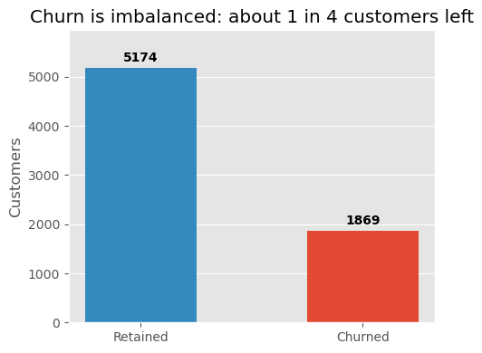

```python
churn_counts = df["Churn"].value_counts()
BASELINE = (df["Churn"] == "Yes").mean() * 100      # the reference line used everywhere

print(churn_counts.to_string())
print(f"\nOverall churn rate: {BASELINE:.2f}%")

fig, ax = plt.subplots(figsize=(5, 4))
bars = ax.bar(["Retained", "Churned"],
              [churn_counts["No"], churn_counts["Yes"]],
              width=0.5, color=[SAFE, RISK])
ax.bar_label(bars, fmt="%d", padding=3, fontweight="bold")
ax.set_ylabel("Customers")
ax.set_title("Churn is imbalanced: about 1 in 4 customers left")
ax.set_ylim(0, churn_counts.max() * 1.15)
ax.grid(axis="x", visible=False)
plt.tight_layout()
plt.show()
```

**Insight.** 1,869 of 7,043 customers churned - **26.54%**. Two consequences:

1. **This is our baseline.** Any group churning noticeably above 26.5% is a risk segment; anything below it is a safe one. Every chart from here on draws it as a dashed line.
2. **The classes are imbalanced** (roughly 3:1). Worth remembering if this data is later used for modelling - a model that simply predicted "nobody churns" would score 73% accuracy while being completely useless.

### A reusable chart helper

Rather than rebuild the same pivot-and-plot code a dozen times, we define it once here. It draws the churn rate for each level of a column, labels each bar with that rate, puts the group size `n` in the tick label underneath, and draws the 26.5% baseline for comparison. Bars at or above the baseline are coloured red (risk), the rest blue (safe).

```python
def churn_by_category(column, data=None, ax=None, title=None, order=None, labels=None):
    # Plot churn rate (%) per level of `column`, annotated with the group size n.
    data = df if data is None else data
    if ax is None:
        _, ax = plt.subplots(figsize=(5, 4))

    rate = data.groupby(column)["Churn"].apply(lambda s: (s == "Yes").mean() * 100)
    size = data[column].value_counts()
    if order is not None:
        rate, size = rate.reindex(order), size.reindex(order)
    size = size.reindex(rate.index)

    # Group size goes in the tick label, where it can never collide with a short bar.
    names = [labels.get(i, str(i)) for i in rate.index] if labels else [str(i) for i in rate.index]
    names = [f"{name}\n(n={n:,})" for name, n in zip(names, size.values)]

    colors = [RISK if v >= BASELINE else SAFE for v in rate.values]
    bars = ax.bar(names, rate.values, width=0.55, color=colors)
    ax.bar_label(bars, fmt="%.1f%%", padding=3, fontweight="bold", fontsize=9)

    ax.axhline(BASELINE, color="#555555", linestyle="--", linewidth=1.2)
    ax.set_ylim(0, max(rate.max() * 1.28, BASELINE * 1.35))
    ax.set_ylabel("Churn rate (%)")
    ax.set_title(title or column)
    ax.grid(axis="x", visible=False)
    return ax

print(f"Helper ready. Baseline churn rate = {BASELINE:.2f}% (the dashed line on every chart)")
```

```
Helper ready. Baseline churn rate = 26.54% (the dashed line on every chart)
```

## 6. Univariate analysis - the shape of each variable

Before comparing anything to churn, it is worth seeing what each variable looks like on its own. Distributions often explain the patterns that show up later.

### 6.1 The three numeric columns

```python
df[["Tenure", "MonthlyCharges", "TotalCharges"]].describe().round(2)
```

|  | Tenure | MonthlyCharges | TotalCharges |
| --- | --- | --- | --- |
| count | 7043.00 | 7043.00 | 7043.00 |
| mean | 32.37 | 64.76 | 2279.73 |
| std | 24.56 | 30.09 | 2266.79 |
| min | 0.00 | 18.25 | 0.00 |
| 25% | 9.00 | 35.50 | 398.55 |
| 50% | 29.00 | 70.35 | 1394.55 |
| 75% | 55.00 | 89.85 | 3786.60 |
| max | 72.00 | 118.75 | 8684.80 |

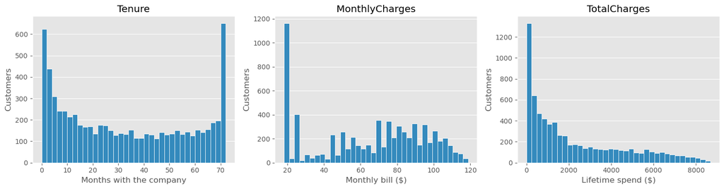

```python
fig, axes = plt.subplots(1, 3, figsize=(15, 4))

specs = [("Tenure",         "Months with the company", 36),
         ("MonthlyCharges", "Monthly bill ($)",        36),
         ("TotalCharges",   "Lifetime spend ($)",      36)]

for ax, (col, xlabel, bins) in zip(axes, specs):
    ax.hist(df[col], bins=bins, color=SAFE, edgecolor="white", linewidth=0.6)
    ax.set_xlabel(xlabel)
    ax.set_ylabel("Customers")
    ax.set_title(col)
    ax.grid(axis="x", visible=False)

plt.tight_layout()
plt.show()
```

**Insights from the three distributions.**

- **`Tenure` is strongly bimodal** - a tall spike at 1-2 months and another at 72 months, with a dip in the middle. The company either loses people almost immediately or keeps them for the full six years. There is not much of a "middle" customer. This single fact shapes the whole analysis: **churn is a new-customer problem.**
- **`MonthlyCharges` is also bimodal**, clustering near `$20 and again across $70-$100`. The low cluster is phone-only customers; the high cluster is internet (especially fiber) bundles. So this column is really a proxy for *which product* a customer has.
- **`TotalCharges` is heavily right-skewed**, which is expected because it is roughly `tenure x monthly` charge. Most customers have accumulated little; a long tail of loyal customers. Median `$1,395 against a mean of \$2,280` confirms the skew.

### 6.2 The categorical columns

```python
 #df["Gender"].value_counts()
```

[output not shown]

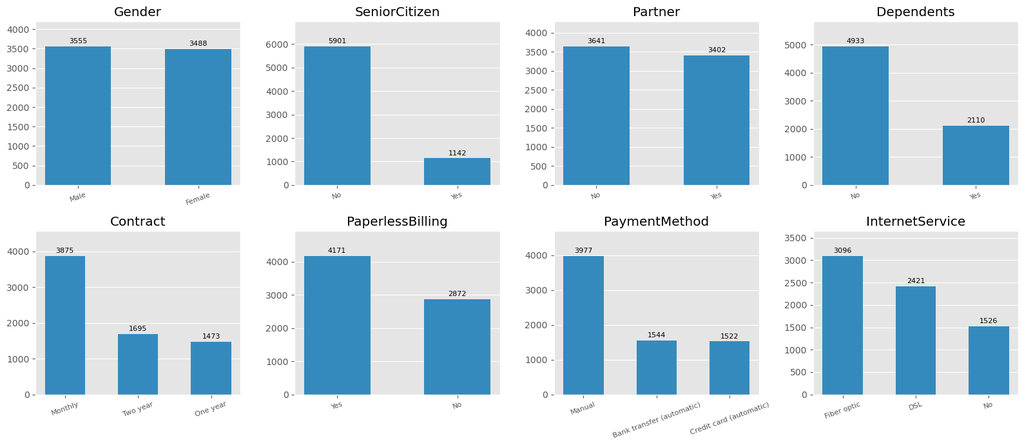

```python
demo_cols = ["Gender", "SeniorCitizen", "Partner", "Dependents",
             "Contract", "PaperlessBilling", "PaymentMethod", "InternetService"]

fig, axes = plt.subplots(2, 4, figsize=(16, 7))
for ax, col in zip(axes.flat, demo_cols):
    counts = df[col].value_counts()
    names = ["No", "Yes"] if col == "SeniorCitizen" else [str(i) for i in counts.index]
    bars = ax.bar(names, counts.values, width=0.55, color=SAFE)
    ax.bar_label(bars, fmt="%d", padding=2, fontsize=8)
    ax.set_title(col)
    ax.set_ylim(0, counts.max() * 1.18)
    ax.grid(axis="x", visible=False)
    ax.tick_params(axis="x", labelrotation=20, labelsize=8)

plt.tight_layout()
plt.show()
```

**Insight.** The customer base is balanced on gender (3,555 male / 3,488 female) but skewed on almost everything else: only **16%** are senior citizens, **55%** are on a *monthly* contract, **59%** use paperless billing, and **56%** pay manually. Fiber optic is the single largest internet product (3,096 customers), and 1,526 customers take no internet at all. Those imbalances matter, because the largest groups are also - as the next section shows - the ones churning fastest.

## 7. Bivariate analysis - what drives churn

This is the heart analysis. For each attribute we ask a single question: **does knowing this about a customer change how likely they are to leave?**

**Remember the reading rule**: bars above the dashed 26.5% line are risk segments.

### 7.1 Demographics - who the customer is

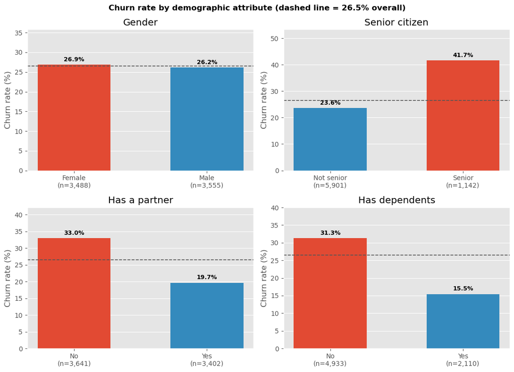

```python
fig, axes = plt.subplots(2, 2, figsize=(11, 8))

churn_by_category("Gender", ax=axes[0, 0], title="Gender")
churn_by_category("SeniorCitizen", ax=axes[0, 1], title="Senior citizen", order=[0, 1], labels={0: "Not senior", 1: "Senior"})
churn_by_category("Partner", ax=axes[1, 0], title="Has a partner")
churn_by_category("Dependents", ax=axes[1, 1], title="Has dependents")

fig.suptitle("Churn rate by demographic attribute (dashed line = 26.5% overall)",fontsize=12, fontweight="bold")
plt.tight_layout()
plt.show()
```

**Insights.**

- **Gender does not matter at all.** 26.9% of women churn against 26.2% of men - a gap of 0.8 points, which is noise. This is worth stating plainly because gender is often the first thing people chart. It should not drive any retention decision.
- **Senior citizens churn at nearly double the rate** of everyone else: **41.7% vs 23.6%**. They are only 16% of the base, but they are one of its most fragile segments.
- **Customers with no partner (33.0%) and no dependents (31.3%)** churn far more than those with a partner (19.7%) or dependents (15.5%).

Taken together, the last two points describe the same underlying customer: a **single-person household**. Family households behave like anchored, multi-user accounts - harder to switch away, and more people depending on the connection. Solo customers can leave suddenly.

### 7.2 Contract and billing - how the customer pays

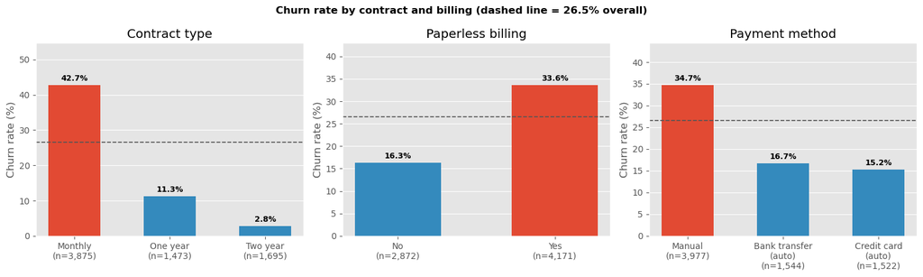

```python
fig, axes = plt.subplots(1, 3, figsize=(15, 4.5))

churn_by_category("Contract", ax=axes[0], title="Contract type",
                  order=["Monthly", "One year", "Two year"])
churn_by_category("PaperlessBilling", ax=axes[1], title="Paperless billing")
churn_by_category("PaymentMethod", ax=axes[2], title="Payment method",
                  order=["Manual", "Bank transfer (automatic)", "Credit card (automatic)"],
                  labels={"Bank transfer (automatic)": "Bank transfer\n(auto)",
                          "Credit card (automatic)": "Credit card\n(auto)"})

fig.suptitle("Churn rate by contract and billing (dashed line = 26.5% overall)",
             fontsize=12, fontweight="bold")
plt.tight_layout()
plt.show()
```

**Insights - this is where the strongest signal in the whole dataset lives.**

- **Contract type is the single biggest driver.** Monthly contracts churn at **42.7%**, one-year at 11.3%, two-year at just **2.8%**. That is a **15x spread** between the extremes, far wider than anything else we measure. And the worst group is also the largest: 3,875 customers - 55% of the base - are on monthly terms.
- **Paperless billing customers churn more than twice as often** (33.6% vs 16.3%). This is almost certainly not the paper itself causing anything - paperless correlates with the newer, monthly, digitally-acquired customers. It is a useful *marker* of risk, not a lever.
- **Manual payment nearly doubles churn** (34.7%) compared with either automatic method (16.7% bank transfer, 15.2% credit card). Every manual payment is a moment where the customer consciously decides to pay again; an automatic payment removes that decision.

**A note on two year contract**: a two-year contract does not magically create loyalty. It partly *selects* for customers who already intended to stay, and it also blocks the ones who want to leave. Both effects are real, and both are commercially useful.

### 7.3 Core services - what the customer buys

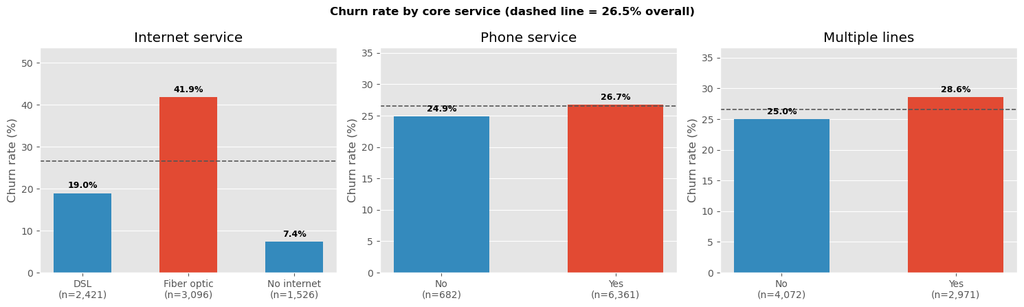

```python
fig, axes = plt.subplots(1, 3, figsize=(15, 4.5))

churn_by_category("InternetService", ax=axes[0], title="Internet service",
                  order=["DSL", "Fiber optic", "No"],
                  labels={"No": "No internet"})
churn_by_category("PhoneService",  ax=axes[1], title="Phone service")
churn_by_category("MultipleLines", ax=axes[2], title="Multiple lines")

fig.suptitle("Churn rate by core service (dashed line = 26.5% overall)",
             fontsize=12, fontweight="bold")
plt.tight_layout()
plt.show()
```

**Insights.**

- **Fiber optic customers churn at 41.9%** - more than double DSL's 19.0%, and they are the largest product group (3,096 customers). This is the most commercially interesting anomaly in the dataset: fiber is the *premium, technically superior* product, yet its customers leave fastest.
- **Customers with no internet churn at only 7.4%** - by far the most loyal group. They are typically low-cost, phone-only, long-tenure customers with very little bill to resent.
- **Phone service is nearly irrelevant** (26.7% with vs 24.9% without), and having multiple lines only nudges churn up (28.6% vs 25.0%).

```python
print(df.groupby("InternetService")[["MonthlyCharges", "Tenure"]].mean().round(2).to_string())
print()
print("Fiber share of all churned customers: "
      f'{(df[df.Churn == "Yes"].InternetService.eq("Fiber optic").mean() * 100):.1f}%')
```

```
                 MonthlyCharges  Tenure
InternetService
DSL                       58.10   32.82
Fiber optic               91.50   32.92
No                        21.08   30.55

Fiber share of all churned customers: 69.4%
```

It is also a large problem, not a niche one: **fiber customers make up 69.4% of everyone who churned.**

### 7.4 Add-on services

```python
# internet = df[df["InternetService"] != "No"]      # internet subscribers only
# print(f"All customers          : n = {len(df):,}")
# print(f"Internet subscribers   : n = {len(internet):,}")
# print(f"Excluded (no internet) : n = {len(df) - len(internet):,}\n")

# addons = ["OnlineSecurity", "OnlineBackup", "DeviceProtection",
#           "TechSupport", "StreamingTV", "StreamingMovies"]

# comparison = pd.DataFrame({
#     "'No' churn %, all customers":   [df[df[c] == "No"]["Churn"].eq("Yes").mean() * 100 for c in addons],
#     "'No' churn %, internet only":   [internet[internet[c] == "No"]["Churn"].eq("Yes").mean() * 100 for c in addons],
# }, index=addons).round(1)
# comparison["distortion"] = (comparison.iloc[:, 1] - comparison.iloc[:, 0]).round(1)
# comparison
```

[output not shown]

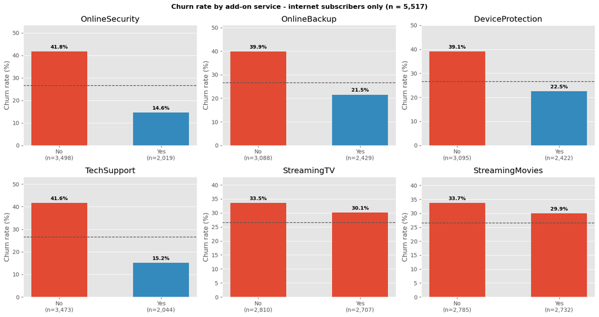

```python
fig, axes = plt.subplots(2, 3, figsize=(15, 8))
for ax, col in zip(axes.flat, addons):
    churn_by_category(col, data=internet, ax=ax, title=col)

fig.suptitle("Churn rate by add-on service - internet subscribers only (n = 5,517)",
             fontsize=12, fontweight="bold")
plt.tight_layout()
plt.show()
```

**Insights - the add-ons split cleanly into two kinds.**

- **Protective add-ons roughly cut churn by two-thirds.** Among internet subscribers, customers without `OnlineSecurity` churn at **41.8%** against **14.6%** for those who have it; `TechSupport` is almost identical (**41.6% vs 15.2%**). `OnlineBackup` (39.9% vs 21.5%) and `DeviceProtection` (39.1% vs 22.5%) point the same way but are noticeably weaker.
- **Streaming add-ons do essentially nothing.** `StreamingTV` (33.5% without vs 30.1% with) and `StreamingMovies` (33.7% vs 29.9%) are nearly flat - spreads of just 3.5 and 3.7 points - the two weakest of the six.

The genuine contrast is therefore between **support-type services**, which make an account stickier by solving problems and building a support relationship, and **entertainment extras**, which add to the bill without creating any attachment. For retention, security and tech support are real tools; streaming is not one.

### 7.5 The numeric columns versus churn

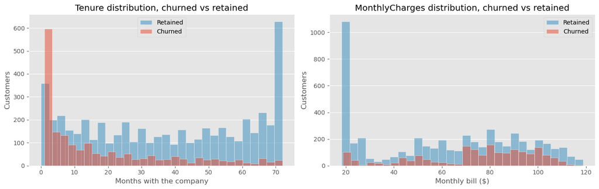

```python
fig, axes = plt.subplots(1, 2, figsize=(14, 4.5))

for ax, col, xlabel in [(axes[0], "Tenure", "Months with the company"),
                        (axes[1], "MonthlyCharges", "Monthly bill ($)")]:
    ax.hist(df[df["Churn"] == "No"][col],  bins=30, alpha=0.5,
            color=SAFE, label="Retained", edgecolor="white", linewidth=0.6)
    ax.hist(df[df["Churn"] == "Yes"][col], bins=30, alpha=0.5,
            color=RISK, label="Churned",  edgecolor="white", linewidth=0.6)
    ax.set_xlabel(xlabel)
    ax.set_ylabel("Customers")
    ax.set_title(f"{col} distribution, churned vs retained")
    ax.legend()
    ax.grid(axis="x", visible=False)

plt.tight_layout()
plt.show()
```

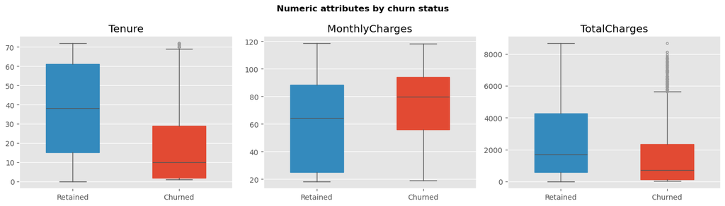

```python
fig, axes = plt.subplots(1, 3, figsize=(14, 4))
for ax, col in zip(axes, ["Tenure", "MonthlyCharges", "TotalCharges"]):
    data = [df[df["Churn"] == "No"][col], df[df["Churn"] == "Yes"][col]]
    bp = ax.boxplot(data, tick_labels=["Retained", "Churned"], patch_artist=True, widths=0.5)
    for patch, colour in zip(bp["boxes"], [SAFE, RISK]):
        patch.set_facecolor(colour)
        patch.set_edgecolor(colour)
    for element in ["whiskers", "caps", "medians"]:
        plt.setp(bp[element], color="#555555")
    plt.setp(bp["fliers"], markeredgecolor="#999999", markersize=3)
    ax.set_title(col)
    ax.grid(axis="x", visible=False)

fig.suptitle("Numeric attributes by churn status", fontsize=12, fontweight="bold")
plt.tight_layout()
plt.show()
```

```python
df.groupby("Churn")[["Tenure", "MonthlyCharges", "TotalCharges"]].mean().round(2)
```

| Churn | Tenure | MonthlyCharges | TotalCharges |
| --- | --- | --- | --- |
| No | 37.57 | 61.27 | 2549.91 |
| Yes | 17.98 | 74.44 | 1531.80 |

**Insights.**

- **Churned customers are new customers.** Mean tenure is **18.0 months for churners against 37.6 for those who stay**, and the churned histogram is dominated by a huge spike in the first few months. The retained distribution, by contrast, piles up at 72 months.
- **Churned customers pay more.** Mean monthly charge is **$74.44 vs $61.27**. The churned histogram is concentrated in the $70-$100 band - exactly where the fiber bundles sit.
- **`TotalCharges` is lower for churners** ($1,532 vs $2,550), but this is arithmetic, not insight: they paid more per month for far fewer months. It is a consequence of the first two findings rather than a separate one.

The profile of a churner is now quite specific: **new, paying a high monthly bill, on a monthly contract, with fiber internet and no support add-ons.**